# Assignment1: TOD Study in Dallas, Texas

Yiming Ma

9/24/2020

## I. Introduction & Motivation

This project focused on the transit-oriented development (TOD) in Dallas. The analysis considers development near existing DART light rail stations. Two specific topics are addressed in detail: 1) whether residents are willing to live near TOD area. 2) whether TOD development is worth the price.

## II. Setup

In this section, we loaded necessary libraries, created plot theme options and map theme options, and identified functions for quintile breaks.

```r
# 1. load Libraries
knitr::opts_chunk$set(echo = TRUE)
options(scipen=999)


library(tidyverse)
library(tidycensus)
library(sf)
library(gridExtra)
library(grid)
library(knitr)
library(kableExtra)
library(rmarkdown)

mapTheme <- function(base_size = 12) {
  theme(
    text = element_text( color = "black"),
    plot.title = element_text(size = 16,colour = "black"),
    plot.subtitle=element_text(face="italic"),
    plot.caption=element_text(hjust=0),
    axis.ticks = element_blank(),
    panel.background = element_blank(),axis.title = element_blank(),
    axis.text = element_blank(),
    axis.title.x = element_blank(),
    axis.title.y = element_blank(),
    panel.grid.minor = element_blank(),
    panel.border = element_rect(colour = "black", fill=NA, size=2),
    strip.text.x = element_text(size = 14))
}

plotTheme <- function(base_size = 12) {
  theme(
    text = element_text( color = "black"),
    plot.title = element_text(size = 16,colour = "black"),
    plot.subtitle = element_text(face="italic"),
    plot.caption = element_text(hjust=0),
    axis.ticks = element_blank(),
    panel.background = element_blank(),
    panel.grid.major = element_line("grey80", size = 0.1),
    panel.grid.minor = element_blank(),
    panel.border = element_rect(colour = "black", fill=NA, size=2),
    strip.background = element_rect(fill = "grey80", color = "white"),
    strip.text = element_text(size=12),
    axis.title = element_text(size=12),
    axis.text = element_text(size=10),
    plot.background = element_blank(),
    legend.background = element_blank(),
    legend.title = element_text(colour = "black", face = "italic"),
    legend.text = element_text(colour = "black", face = "italic"),
    strip.text.x = element_text(size = 14)
  )
}

# 3. Identify functions
qBr <- function(df, variable, rnd) {
  if (missing(rnd)) {
    as.character(quantile(round(df[[variable]],0),
                          c(.01,.2,.4,.6,.8), na.rm=T))
  } else if (rnd == FALSE | rnd == F) {
    as.character(formatC(quantile(df[[variable]]), digits = 3),
                 c(.01,.2,.4,.6,.8), na.rm=T)
  }
}

q5 <- function(variable) {as.factor(ntile(variable, 5))}


multipleRingBuffer <- function(inputPolygon, maxDistance, interval)
{
  #create a list of distances that we'll iterate through to create each ring
  distances <- seq(0, maxDistance, interval)
  #we'll start with the second value in that list - the first is '0'
  distancesCounter <- 2
  #total number of rings we're going to create
  numberOfRings <- floor(maxDistance / interval)
  #a counter of number of rings
  numberOfRingsCounter <- 1
  #initialize an otuput data frame (that is not an sf)
  allRings <- data.frame()

  #while number of rings  counteris less than the specified nubmer of rings
  while (numberOfRingsCounter <= numberOfRings)
  {
    #if we're interested in a negative buffer and this is the first buffer
    #(ie. not distance = '0' in the distances list)
    if(distances[distancesCounter] < 0 & distancesCounter == 2)
    {
      #buffer the input by the first distance
      buffer1 <- st_buffer(inputPolygon, distances[distancesCounter])
      #different that buffer from the input polygon to get the first ring
      buffer1_ <- st_difference(inputPolygon, buffer1)
      #cast this sf as a polygon geometry type
      thisRing <- st_cast(buffer1_, "POLYGON")
      #take the last column which is 'geometry'
      thisRing <- as.data.frame(thisRing[,ncol(thisRing)])
      #add a new field, 'distance' so we know how far the distance is for a give ring
      thisRing$distance <- distances[distancesCounter]
    }


    #otherwise, if this is the second or more ring (and a negative buffer)
    else if(distances[distancesCounter] < 0 & distancesCounter > 2)
    {
      #buffer by a specific distance
      buffer1 <- st_buffer(inputPolygon, distances[distancesCounter])
      #create the next smallest buffer
      buffer2 <- st_buffer(inputPolygon, distances[distancesCounter-1])
      #This can then be used to difference out a buffer running from 660 to 1320
      #This works because differencing 1320ft by 660ft = a buffer between 660 & 1320.
      #bc the area after 660ft in buffer2 = NA.
      thisRing <- st_difference(buffer2,buffer1)
      #cast as apolygon
      thisRing <- st_cast(thisRing, "POLYGON")
      #get the last field
      thisRing <- as.data.frame(thisRing$geometry)
      #create the distance field
      thisRing$distance <- distances[distancesCounter]
    }

    #Otherwise, if its a positive buffer
    else
    {
      #Create a positive buffer
      buffer1 <- st_buffer(inputPolygon, distances[distancesCounter])
      #create a positive buffer that is one distance smaller. So if its the first buffer
      #distance, buffer1_ will = 0.
      buffer1_ <- st_buffer(inputPolygon, distances[distancesCounter-1])
      #difference the two buffers
      thisRing <- st_difference(buffer1,buffer1_)
      #cast as a polygon
      thisRing <- st_cast(thisRing, "POLYGON")
      #geometry column as a data frame
      thisRing <- as.data.frame(thisRing[,ncol(thisRing)])
      #add teh distance
      thisRing$distance <- distances[distancesCounter]
    }

    #rbind this ring to the rest of the rings
    allRings <- rbind(allRings, thisRing)
    #iterate the distance counter
    distancesCounter <- distancesCounter + 1
    #iterate the number of rings counter
    numberOfRingsCounter <- numberOfRingsCounter + 1
  }

  #convert the allRings data frame to an sf data frame
  allRings <- st_as_sf(allRings)
}

palette5 <- c("#CCCCFF","#CC99FF","#9966CC","#663399","#330066")

# Load API
census_api_key("a7edab3d7c3df571998caab5a3cc12a4ec8d8b61" , overwrite  = TRUE)
```

## III. Data Manipulation and Visualization

### 1. Data Wrangling

The DART transit system information, crime data, census data were downloaded from the following sources:

- Demographic variables from the ACS 2009 and 2017 for census tracts in Dallas County.
- [DART](https://hub.arcgis.com/datasets/DallasGIS::dart-rail-stations) Railway station in geojson format.
- Case-level [burglary crime data](https://www.dallasopendata.com/browse?category=Public+Safety&limitTo=datasets&provenance=official) in 2017.

#### 1.1 Fetch Census Data

The following demographic variables was selected from the ACS 2009 and 2017 for census tracts in Dallas County:

```r
# ---- 2009 Census Data -----
tracts09 <-
  get_acs(geography = "tract", variables = c("B25026_001E","B02001_002E","B15001_050E",
                                             "B15001_009E","B19013_001E","B25058_001E",
                                             "B06012_002E"),
          year=2009, state= 48, county= 113, geometry=T) %>%
  st_transform('EPSG:32138')


tracts09 <-
  tracts09 %>%
  dplyr::select( -NAME, -moe) %>%
  spread(variable, estimate) %>%
  dplyr::select(-geometry) %>%
  rename(TotalPop = B25026_001,
         Whites = B02001_002,
         FemaleBachelors = B15001_050,
         MaleBachelors = B15001_009,
         MedHHInc = B19013_001,
         MedRent = B25058_001,
         TotalPoverty = B06012_002)


tracts09 <-
  tracts09 %>%
  mutate(pctWhite = ifelse(TotalPop > 0, Whites / TotalPop, 0),
         pctBachelors = ifelse(TotalPop > 0, ((FemaleBachelors + MaleBachelors) / TotalPop * 100), 0),
         pctPoverty = ifelse(TotalPop > 0, TotalPoverty / TotalPop, 0),
         year = "2009") %>%
  dplyr::select(-Whites,-FemaleBachelors,-MaleBachelors,-TotalPoverty)

# ---- 2017 Census Data -----

tracts17 <-
  get_acs(geography = "tract", variables = c("B25026_001E","B02001_002E","B15001_050E",
                                             "B15001_009E","B19013_001E","B25058_001E",
                                             "B06012_002E"),
          year=2017, state= 48, county= 113, geometry=T, output="wide") %>%
  st_transform('EPSG:32138') %>%
  rename(TotalPop = B25026_001E,
         Whites = B02001_002E,
         FemaleBachelors = B15001_050E,
         MaleBachelors = B15001_009E,
         MedHHInc = B19013_001E,
         MedRent = B25058_001E,
         TotalPoverty = B06012_002E) %>%
  dplyr::select(-NAME, -starts_with("B")) %>% #-starts_with("B") awesome!
  mutate(pctWhite = ifelse(TotalPop > 0, Whites / TotalPop,0),
         pctBachelors = ifelse(TotalPop > 0, ((FemaleBachelors + MaleBachelors) / TotalPop * 100),0),
         pctPoverty = ifelse(TotalPop > 0, TotalPoverty / TotalPop, 0),
         year = "2017") %>%
  dplyr::select(-Whites, -FemaleBachelors, -MaleBachelors, -TotalPoverty)

# --- Combining 09 and 17 data ----

allTracts <- rbind(tracts09,tracts17)
```

#### 1.2 Load Dallas Transit Data

As of 2017, DART has four lines and 64 stations, spreading from downtown to various directions.

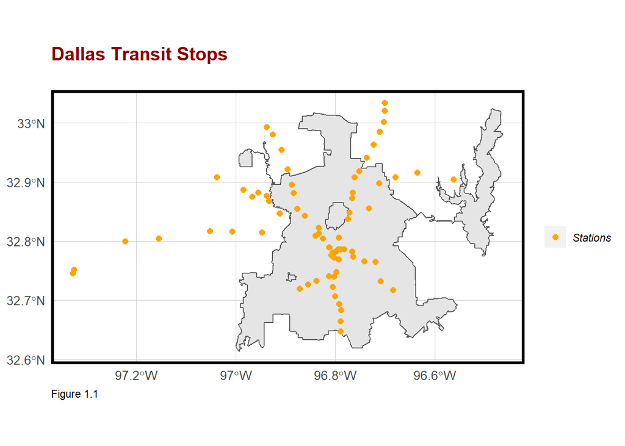

```r
ggplot() +
  geom_sf(data= Dallas) +
  geom_sf(data=D_Stops,
          aes(color = 'orange'),
          show.legend = "point", size= 2) +
  scale_colour_manual(values = c("orange"),
                      labels = 'Stations',
                      name = ' ') +
  labs(title="Dallas Transit Stops",
       subtitle=" ",
       caption="Figure 1.1") +
  plotTheme() +
  theme(plot.title = element_text(color = "darkred", size=15, face="bold"))
```

#### 1.3 Identifying TOD Tracts

Adding a 0.5 mile buffer to each station, the TOD tracts were selected by centroids. As shown in Figure 1, the TOD area did not change much from 2009 to 2017. Instead, TOD area shrinks in northeast and northwest Dallas.

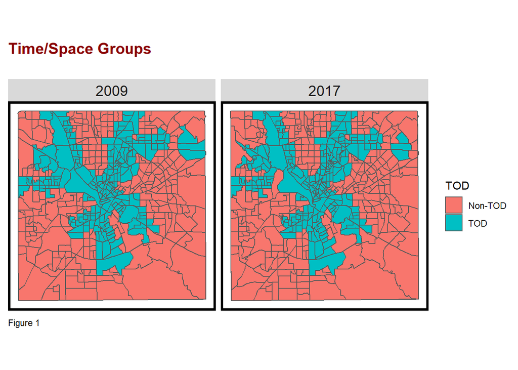

```r
D_Buffers <-
  rbind(
    st_buffer(D_Stops, 2640) %>%
      mutate(Legend = "Buffer") %>%
      dplyr::select(Legend),
    st_union(st_buffer(D_Stops, 2640)) %>%
      st_sf() %>%
      mutate(Legend = "Unioned Buffer"))
buffer <- filter(D_Buffers, Legend=="Unioned Buffer")

selectCentroids <-
  st_centroid(tracts09)[buffer,] %>%
  st_drop_geometry() %>%
  left_join(dplyr::select(tracts09, GEOID)) %>%
  st_sf() %>%
  dplyr::select(TotalPop) %>%
  mutate(Selection_Type = "Select by Centroids")

head(selectCentroids,5)

# Census Data in Group by TODs
allTracts.group <-
  rbind(
    st_centroid(allTracts)[buffer,] %>%
      st_drop_geometry() %>%
      left_join(allTracts) %>%
      st_sf() %>%
      mutate(TOD = "TOD"),
    st_centroid(allTracts)[buffer, op = st_disjoint] %>%
      st_drop_geometry() %>%
      left_join(allTracts) %>%
      st_sf() %>%
      mutate(TOD = "Non-TOD")) %>%
  mutate(MedRent.inf = ifelse(year == "2009", MedRent * 1.14, MedRent))  # inflation

# TOD and Non-TOD between 2009 and 2017
ggplot(allTracts.group)+
  geom_sf(data = st_union(tracts09))+
  geom_sf(aes(fill = TOD)) +
  labs(title = "Time/Space Groups",
       subtitle = '',
       caption = 'Figure 1') +
  facet_wrap(~year)+
  mapTheme() +
  theme(plot.title = element_text(color = "darkred", size=15, face="bold"))
```

### 2. Changes in Census Variables Over Time and Space

Through time and space, the census variables went through following changes:

- Median rent increased in both TOD and non-TOD tracts.
- Bachelor Degree holder increased substantially in TOD tracts.
- Median household income increased in both TOD and non-TOD tracts.

While the following variables generally remains the same:

- Percentage of white population.

#### 2.1 Median Rent Comparison between 2009 and 2017

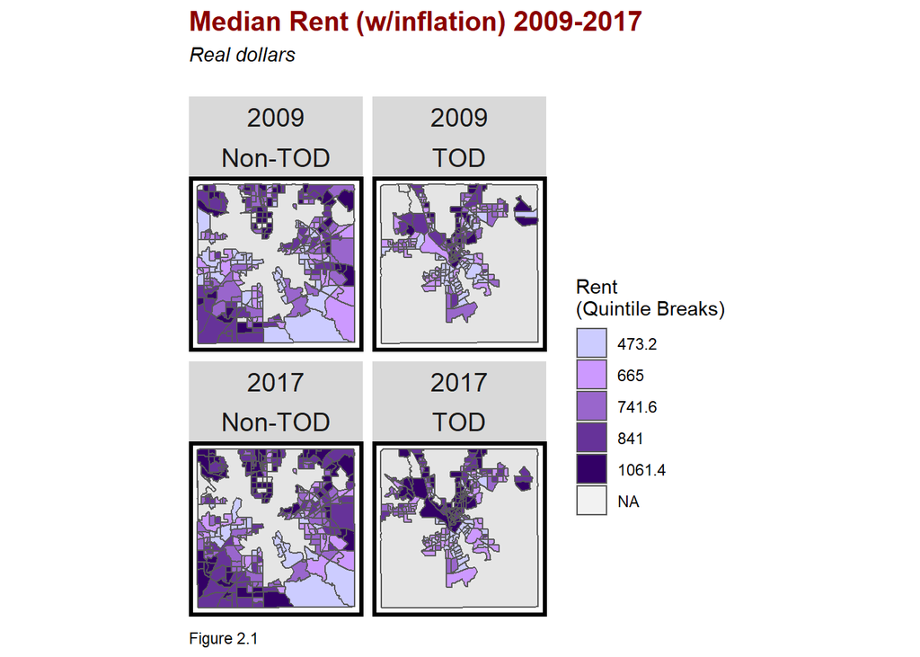

```r
ggplot(allTracts.group)+
  geom_sf(data = st_union(tracts09))+
  geom_sf(aes(fill = q5(MedRent.inf))) +
  scale_fill_manual(values = palette5,
                    labels = qBr(allTracts.group, "MedRent.inf"),
                    name = "Rent\n(Quintile Breaks)") +
  labs(title = "Median Rent (w/inflation) 2009-2017",
       subtitle = "Real dollars \n",
       caption = 'Figure 2.1') +
  facet_wrap(c(~year, ~TOD))+
  mapTheme() +
  theme(plot.title = element_text(color = "darkred", size=15, face="bold"))
```

#### 2.2 Percentage of White Group between 2009 and 2017

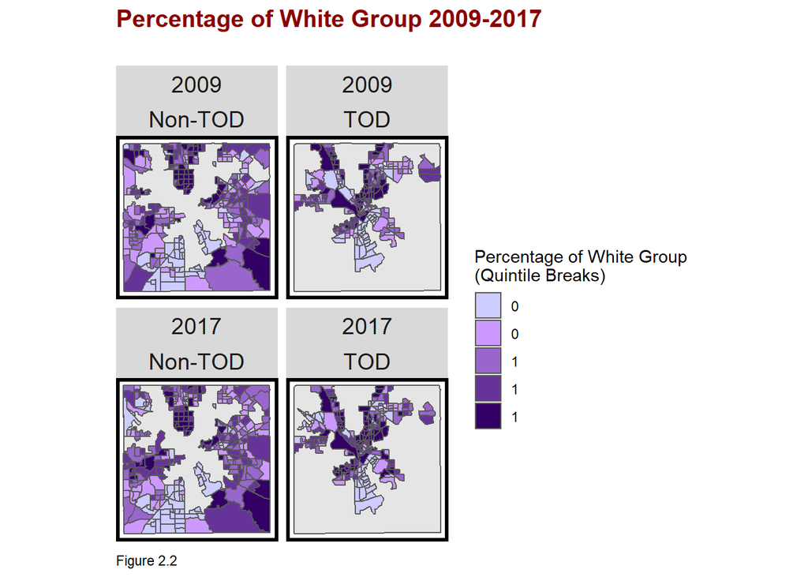

```r
ggplot(allTracts.group)+
  geom_sf(data = st_union(tracts09)) +
  geom_sf(aes(fill = q5(pctWhite))) +
  scale_fill_manual(values = palette5,
                    labels = qBr(allTracts.group, "pctWhite"),
                    name = "Percentage of White Group\n(Quintile Breaks)") +
  labs(title = "Percentage of White Group 2009-2017",
       subtitle = '',
       caption = 'Figure 2.2') +
  facet_wrap(c(~year,~TOD))+
  mapTheme() +
  theme(plot.title = element_text(color = "darkred", size=15, face="bold"))
```

#### 2.3 Bachelor Degree Comparison between 2009 and 2017

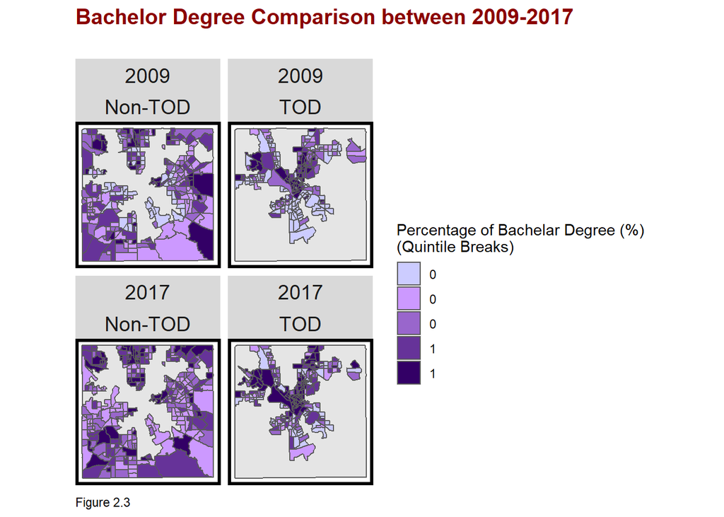

```r
ggplot(allTracts.group)+
  geom_sf(data = st_union(tracts09))+
  geom_sf(aes(fill = q5(pctBachelors))) +
  scale_fill_manual(values = palette5,
                    labels = qBr(allTracts.group, "pctBachelors"),
                    name = "Percentage of Bachelar Degree (%)\n(Quintile Breaks)") +
  labs(title = "Bachelor Degree Comparison between 2009-2017",
       subtitle = '',
       caption = 'Figure 2.3') +
  facet_wrap(c(~year,~TOD))+
  mapTheme() +
  theme(plot.title = element_text(color = "darkred", size=15, face="bold"))
```

#### 2.4 Median Household Income Comparison between 2009 and 2017

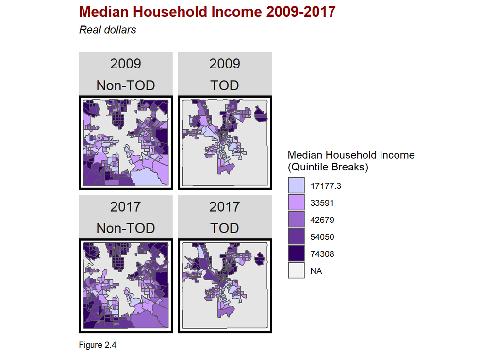

```r
ggplot(allTracts.group)+
  geom_sf(data = st_union(tracts09))+
  geom_sf(aes(fill = q5(MedHHInc))) +
  scale_fill_manual(values = palette5,
                    labels = qBr(allTracts.group, "MedHHInc"),
                    name = "Median Household Income\n(Quintile Breaks)") +
  labs(title = "Median Household Income 2009-2017",
       subtitle = 'Real dollars \n',
       caption = 'Figure 2.4') +
  facet_wrap(c(~year,~TOD))+
  mapTheme() +
  theme(plot.title = element_text(color = "darkred", size=15, face="bold"))
```

### 3. Bar Plot Comparisons

The barplots side by side makes the comparison even easier.As shown in the barplot, the following changes were witnessed:

- Bachelor degree percentage in TOD tracts increased substantially.
- Median income increased in both TOD and non-TOD tracts.
- Median rent increased substantially in both TOD and non-TOD tracts.

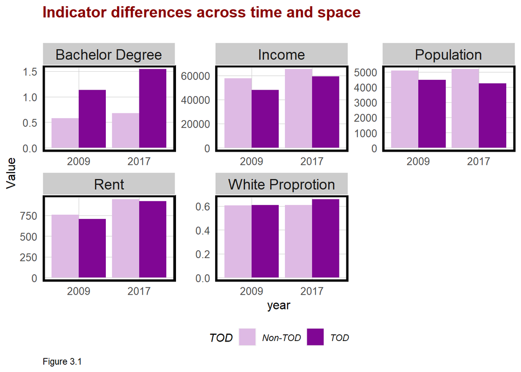

```r
allTracts.Summary <-
  st_drop_geometry(allTracts.group) %>%
  group_by(year, TOD) %>%
  summarize(Rent = mean(MedRent, na.rm = T),
            Population = mean(TotalPop, na.rm = T),
            `White Proprotion` = mean(pctWhite, na.rm = T),
            `Bachelor Degree` = mean(pctBachelors, na.rm = T),
            Income = mean(MedHHInc, na.rm = T))

allTracts.Summary %>%
  gather(Variable, Value, -year, -TOD) %>%
  ggplot(aes(year, Value, fill = TOD)) +
  geom_bar(stat = "identity", position = "dodge") +
  facet_wrap(~Variable, scales = "free", ncol = 3) +
  scale_fill_manual(values = c("#debae4", "#800694")) +
  labs(title = "Indicator differences across time and space \n",
       caption = 'Figure 3.1') +
  plotTheme() +
  theme(legend.position="bottom") +
  theme(plot.title = element_text(color = "darkred", size=15, face="bold"))
```

### 4. Table Comparisons

Table 4.1 presents the same information in a more precise way. We can quantify some major changes mentioned above:

- Median rent increased 30% in TOD tracts, increased 25% in non-TOD tracts.
- Bachelor Degree holder increased 36% in TOD tracts.
- Median income increased 24% in TOD tracts.

```r
allTracts.Summary %>%
  unite(year.TOD, year, TOD, sep = ": ", remove = T) %>%
  gather(Variable, Value, -year.TOD) %>%
  mutate(Value = round(Value, 2)) %>%
  spread(year.TOD, Value) %>%
  kable() %>%
  kable_styling() %>%
  footnote(general_title = "\n",
           general = "Table 4.1")
```

| Variable | 2009: Non-TOD | 2009: TOD | 2017: Non-TOD | 2017: TOD |
| --- | --- | --- | --- | --- |
| Bachelor Degree | 0.58 | 1.13 | 0.68 | 1.54 |
| Income | 57573.74 | 47845.36 | 65220.27 | 59105.64 |
| Population | 5101.41 | 4479.06 | 5186.17 | 4255.57 |
| Rent | 756.44 | 706.39 | 947.34 | 921.06 |
| White Proprotion | 0.61 | 0.61 | 0.61 | 0.66 |

Table 4.1

### 5. Graduated Symbol Maps

Let’s now look at population and rent within 0.5 miles of each transit station. In Figure 5.1, several points along TOD tracks stands out: Victory (in the middle), Walnut Hill (Northwest), UNT Dallas (South). Those are the tracts with more population. In Figure 5.2, we can see that median rent was generally higher in downtown Dallas, and along the line of Northeast TOD area as well. Combining the two, there is no direct relationship between population and rent in TOD tracts. Downtown Dallas is the only area with both bigger population size and high rent.

#### 5.1 Population within 0.5 mile of each transit station

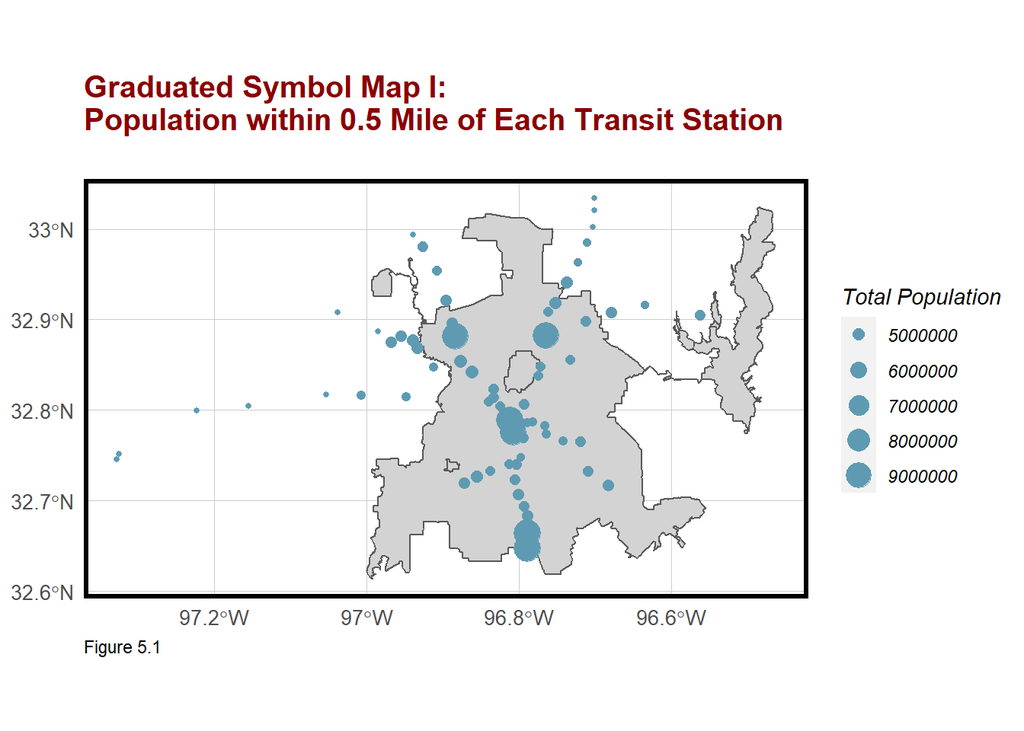

```r
popByStation <-
  join_data %>%
  group_by(STA_NAME) %>%
  summarize(`Total Population` = sum(TotalPop)) %>%
  dplyr::select(STA_NAME, `Total Population`) %>%
  st_drop_geometry() %>%
  left_join(D_Stops)

popByStation_sf <- popByStation %>%
  st_sf()

ggplot() +
  geom_sf(data = Dallas, fill = 'lightgrey') +
  geom_sf(data = popByStation_sf, aes(size = `Total Population`), color = '#5e9bb2') +
  labs(title = "Graduated Symbol Map I: \nPopulation within 0.5 Mile of Each Transit Station" ,
       subtitle = '',
       caption = "Figure 5.1",
       fill = 'Total Population') +
  plotTheme() +
  theme(legend.position="right") +
  theme(plot.title = element_text(color = "darkred", size=15, face="bold"))
```

#### 5.2 Median rent within 0.5 mile of each transit station

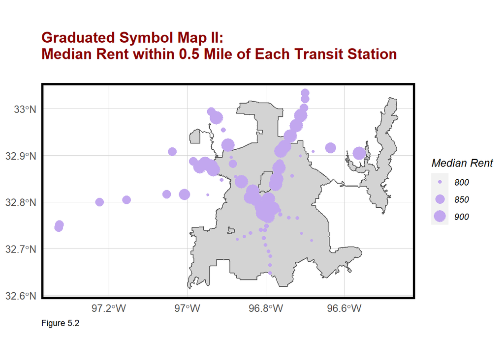

```r
rentByStation <-
  join_data %>%
  group_by(STA_NAME) %>%
  summarize(`Median Rent` = median(na.omit(MedRent))) %>%
  dplyr::select(STA_NAME, `Median Rent`)  %>%
  st_drop_geometry() %>%
  left_join(D_Stops)

rentByStation_sf <- rentByStation %>%
  st_sf()

ggplot() +
  geom_sf(data = Dallas, fill = 'lightgrey') +
  geom_sf(data = rentByStation_sf, aes(size = `Median Rent`), color = '#c2a7ef')  +
  labs(title = "Graduated Symbol Map II: \nMedian Rent within 0.5 Mile of Each Transit Station",
       subtitle = '',
       caption = "Figure 5.2") +
  plotTheme() +
  theme(legend.position="right") +
  theme(plot.title = element_text(color = "darkred", size=15, face="bold"))
```

### 6. Mean Rent as a function of distance to subway stations

The distance to transit station might be a factor that affects rent level. Plot 6.1 illustrated the relationships. In fact, houses adjacent transit stations and away 2 miles have the lowest rent. Houses 1 mile away and 2 miles further tend to have higher rents. From 2009 to 2017, median rent increased overall, despite distance from the transit stations.

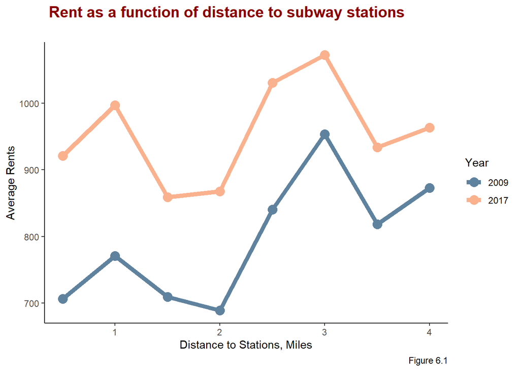

```r
allTracts.rings <-
  st_join(st_centroid(dplyr::select(allTracts, GEOID, year)),
          multipleRingBuffer(st_union(D_Stops), 47520, 2640)) %>%
  st_drop_geometry() %>%
  left_join(dplyr::select(allTracts, GEOID, MedRent, year),
            by=c("GEOID"="GEOID", "year"="year")) %>%
  st_sf() %>%
  mutate(distance = distance / 5280)

allTracts.rings <- na.omit(allTracts.rings)

mean_RENT <- allTracts.rings %>%
  group_by(year, distance) %>%
  summarize(mean_RENT = mean(MedRent))

ggplot(data = mean_RENT) +
  geom_line(aes(x = distance, y = mean_RENT, col = year), size = 2) +
  geom_point(aes(x = distance, y = mean_RENT, col = year) , size = 4) +
  labs(title = " Rent as a function of distance to subway stations",
       subtitle = '',
       caption = 'Figure 6.1') +
  scale_color_manual(values = c('#5f829e','#fab18e'),
                     name = 'Year') +
  theme(legend.position = "right") +
  xlab("Distance to Stations, Miles") +
  ylab("Average Rents") +
  theme_classic() +
  theme(plot.title = element_text(color = "darkred", size=15, face="bold"))
```

### 7. Crime Rate, Transit Access and Rents

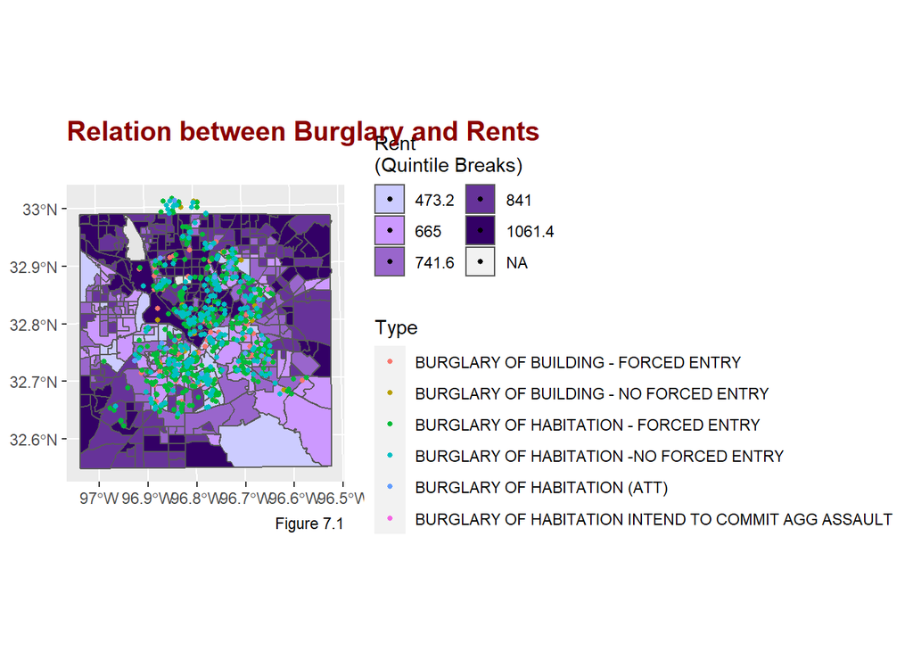

```r
# 1. Load Crime-Burglary Data
crime_dat <- read.csv('Dallas_Crime_Data.CSV')

crime_dat_point <- st_as_sf(crime_dat, coords = c("Longitude", "Latitude"), crs = 4326, agr = "constant") %>%
  select(Type, geometry)

# 2. Plot Relation between Burglary and Rents
ggplot(allTracts.group) +
geom_sf(data = st_union(tracts09))+
  geom_sf(aes(fill = q5(MedRent.inf))) +
  geom_sf(data = crime_dat_point,
          aes(color = Type),
          show.legend = 'point',size = 1) +
  scale_fill_manual(values = palette5,
                    labels = qBr(allTracts.group, "MedRent.inf"),
                    name = "Rent\n(Quintile Breaks)")  +
  labs(title = "Relation between Burglary and Rents \n",
       caption = 'Figure 7.1') +
  theme(legend.position="right") +
  guides(fill=guide_legend(ncol=2)) +
  theme(plot.title = element_text(color = "darkred", size=15, face="bold"))
```

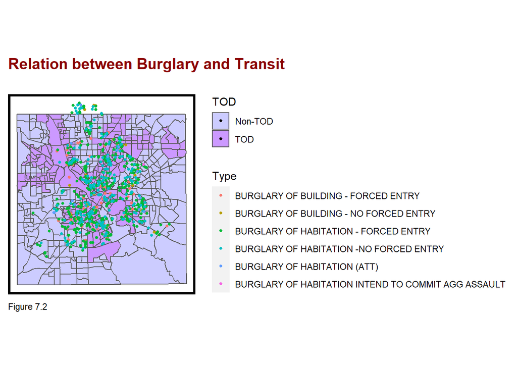

```r
# 3. Plot Relation between Burglary and Transit
ggplot(allTracts.group)+
  geom_sf(data = st_union(tracts09))+
  geom_sf(aes(fill = TOD)) +
  scale_fill_manual(values = palette5) +

  geom_sf(data = crime_dat_point,
          aes(color = Type),
          show.legend = 'point',size = 1) +
  labs(title = "Relation between Burglary and Transit \n",
       caption = 'Figure 7.2') +
  theme(legend.position="right") +
  mapTheme() +
  theme(plot.title = element_text(color = "darkred", size=15, face="bold"))
```

## IV. Conclusion and Recommandation

- Extend the light trail lines and let more residents get access to public transit.
- Set financial incentives to attract mix-income housing and jobs to TOD areas.
- Address on safety issues and guarantee a safe living environment.

To maintain and enhance the positive effect of TOD, more demographic and social factors aside the ones adopted in this report need to be considered. Policy objectives need to be revised and updated constantly along with the development of the city.